# R Notebook

```r
library(readr)
library(dplyr)
```

```r
library(ggplot2)
library(ggthemes)
library(descr)
BD <- read_csv("BDP1.csv")
```

## **Introducción**

### - **Relevancia:**

##### El confinamiento por la pandemia del COVID-19 ocasionó cambios en la vida cotidiana dentro de la población peruana. Originó distintas reacciones como la preocupación, estrés, ansiedad y miedo, que a su vez repercutieron de forma drástica en los hábitos alimenticios (conjunto de conductas de las personas, relacionadas con la selección y consumo de alimentos) de los estudiantes que a largo plazo originaron consecuencias en su salud y bienestar. Para ello, es necesario tener un panorama claro del impacto de la pandemia en este sector. Existen diversos estudios como los de Restrepo (2020), Tazeoğlu, A.(2021) y Velázquez, J. (2020). que analizan temas de alimentación relacionados con los de la pandemia del COVID-19 en jóvenes. A partir de una idea de ello, este proyecto se encarga de analizar algunos de los posibles factores que alteraron las rutinas alimenticias en base a algunos cambios físicos y psicológicos que padecieron durante todo este periodo. Además, este proyecto busca aportar en la toma de decisiones de diversas instituciones tanto públicas y privadas, por ejemplo, en la elaboración de proyectos a favor de la población en relación a programas de ayuda alimentaria. Cabe mencionar que este proyecto también analizará los nuevos hábitos sobre la alimentación a los que los estudiantes se adaptaron, considerando que diversos factores como la falta de estabilidad financiera o trastornos mentales pudieron ocasionar un deterioro en la calidad de consumo de nuestros alimentos cotidianos, exponiendo a los estudiantes a otro tipo de patologías. Nuestra pregunta de investigación es: ¿Cuál es el impacto del confinamiento por la pandemia del COVID-19 en el consumo de productos alimenticios en los jóvenes estudiantes de la Universidad de Ingeniería y Tecnología?. Nuestros objetivos son los siguientes:

#### *Objetivos generales:*

- Determinar el impacto del confinamiento en la alimentación de los estudiantes de la Universidad de Ingeniería y Tecnología
- Determinar los factores que influyeron en el cambio de alimentación por la pandemia de la COVID-19 en los estudiantes de la Universidad de Ingeniería y Tecnología
- Analizar los hábitos alimenticios actuales de los estudiantes de la Universidad de Ingeniería y Tecnología

#### *Objetivos específicos:*

- Comparar el Índice de Masa Corporal (IMC) antes y después del confinamiento en los estudiantes de la Universidad de Ingeniería y Tecnología
- Determinar las causas que influyeron en el cambio de alimentación por el confinamiento en los estudiantes de la Universidad de Ingeniería y Tecnología
- Determinar el impacto del confinamiento en el consumo de frutas y verduras en los estudiantes de la Universidad de Ingeniería y Tecnología
- Determinar el impacto del confinamiento en el consumo de carnes (rojas, blancas) en los estudiantes de la Universidad de Ingeniería y Tecnología
- Determinar el impacto del confinamiento en el consumo de bebidas (alcohólicas, azucaradas) en los estudiantes de la Universidad de Ingeniería y Tecnología
- Determinar el impacto del confinamiento en el consumo de snacks y dulces en los estudiantes de la Universidad de Ingeniería y Tecnología
- Determinar el impacto del confinamiento en el consumo de suplementos de vitaminas en los estudiantes de la Universidad de Ingeniería y Tecnología
- Determinar el impacto del confinamiento en el consumo de frutos secos en los estudiantes de la Universidad de Ingeniería y Tecnología
- Determinar el impacto del confinamiento en la frecuencia de practica y actividades físicas en los estudiantes de la Universidad de Ingeniería y Tecnología
- Determinar la Influencia del lugar de residencia en el cambio de alimentación por el confinamiento de los estudiantes de la Universidad de Ingeniería y Tecnología
- Determinar la influencia de las personas con las que se convivió durante el confinamiento en el cambio de alimentación de los estudiantes de la Universidad de Ingeniería y Tecnología
- Determinar la influencia de los estados de ánimo en la alimentación de los estudiantes de la Universidad de Ingeniería y Tecnología
- Conocer el cambio de alimentación de los estudiantes de la Universidad de Ingeniería y Tecnología por el confinamiento según su género.
- Establecer 2 modelos lineales que relacione el peso y la talla antes y después del confinamiento de los estudiantes de la Universidad de Ingeniería y Tecnología
- Estimar el número de veces representativo del consumo de alimentos por día de los estudiantes de la Universidad de Ingeniería y Tecnología
- Determinar el tipo de alimentación actual de la mayoría de los estudiantes de la Universidad de Ingeniería y Tecnología, a partir de la omisión de comidas por día
- Determinar la predisposición de los estudiantes de la Universidad de Ingeniería y Tecnología para la mejora de sus hábitos alimenticios

### **Datos**

### - **Recolección de datos:**

##### Nuestro proceso de recolección de datos fue a través del uso de encuestas, formularios de Google. Una herramienta que a través de la elaboración de una serie de preguntas concretas, nos proporcionó la suficiente información acerca de los diferentes puntos de vista de cada individuo. Y una vez recolectado estos datos, se hace uso de dicha información para el planteamiento del proyecto de investigación. Como estudiantes pertenecientes a la universidad, la estrategia utilizada fue por medio del envió de estas encuestas por las redes sociales de los demás estudiantes, como por servicios de mensajería. Ya que de esta manera, tenemos una mayor acercamiento o llegada hacia nuestro publico objetivo. Por la principal razón que el uso de estas redes son de forma masiva, y muy comunes dentro del sector juvenil. Por lo que se nos facilito el contacto con este.

### - **Población, muestra y muestreo:**

##### La población de nuestro proyecto de estudio es la población estudiantil de la Universidad de Ingeniería y Tecnología (UTEC). Asímismo, la unidad muestral es el estudiante de carrera. El tamaño recolectado de esta muestra fue de un total de 205 estudiantes. Este subconjunto es representativo de la población por el motivo que el objeto de estudio que está enfocado de manera general en el análisis del impacto en los estudiantes de la Universidad de Ingeniería y Tecnología. El muestreo realizado fue por el tipo probabilístico “aleatorio simple”. Es decir, se seleccionaron de manera aleatoria, por producto del azar, a los elementos de nuestra población. De tal manera que este tipo tiene como característica en que cada muestra tiene la misma probabilidad de ser escogido.

### - **Variables:**

- Edad: Es una variable numérica discreta y su restricción es que sea un entero no negativo.
- Género: Es una variable categórica nominal y su restricción es que solo el usuario responderá obligatoriamente una de las dos opciones.
- Lugar de residencia: Es una variable categórica nominal y su restricción es que solo se puede escoger una de las siete opciones.
- Peso antes del confinamiento: Es una variable numérica continua y su restricción es que sea un decimal no negativo y mayor que 40.
- Peso después del confinamiento: Es una variable numérica continua y su restricción es que sea un decimal no negativo y mayor que 40.
- Convivencia durante el confinamiento: Es una variable categórica nominal y su restricción es que solo se puede escoger una opción.
- Sentimientos durante el confinamiento: Es una variable categórica nominal y su restricción es que solo se puede escoger una opción.
- Consumo de frutas y verduras durante el confinamiento: Es una variable categórica nominal y su restricción es que solo se puede escoger una de las cuatro opciones.
- Consumo de carnes rojas durante el confinamiento: Es una variable categórica nominal y su restricción es que solo se puede escoger una de las cuatro opciones.
- Consumo de carnes blancas durante el confinamiento: Es una variable categórica nominal y su restricción es que solo se puede escoger una de las cuatro opciones.
- Consumo de huevos durante el confinamiento: Es una variable categórica nominal y su restricción es que solo se puede escoger una de las cuatro opciones.
- Consumo de lácteos durante el confinamiento: Es una variable categórica nominal y su restricción es que solo se puede escoger una de las cuatro opciones.
- Consumo de pan y cereales durante el confinamiento: Es una variable categórica nominal y su restricción es que solo se puede escoger una de las cuatro opciones.
- Consumo de suplementos de vitaminas durante el confinamiento: Es una variable categórica nominal y su restricción es que solo se puede escoger una de las cuatro opciones.
- Consumo de bebidas alcohólicas durante el confinamiento: Es una variable categórica nominal y su restricción es que solo se puede escoger una de las cuatro opciones.
- Percepción sobre el cambio de alimentación por el confinamiento: Es una variable categórica nominal y su restricción es que solo se puede escoger una opción.
- Causas del cambio de alimentación durante el confinamiento: Es una variable categórica nominal y su restricción es que solo se puede escoger una opción.
- Percepción sobre su alimentación actual: Es una variable categórica nominal y su restricción es que solo se puede escoger una opción.
- Veces de consumo de alimentos por día: Es una variable numérica discreta y su restricción es que solo se puede escoger una opción de la escala dada.
- Omisión de comidas: Es una variable categórica nominal y su restricción es que solo se puede escoger una opción.
- Percepción sobre la mejora de sus hábitos alimenticios: Es una variable categórica nominal y su restricción es que solo se puede escoger una opción.
- Frecuencia de práctica de actividad física antes del confinamiento: Es una variable categórica ordinal y su restricción es que solo se puede escoger una opción.
- Frecuencia de práctica de actividad física después del confinamiento: Es una variable categórica ordinal y su restricción es que solo se puede escoger una opción.
- Estatura antes del confinamiento: Es una variable numérica continua y su restricción es que sea un número decimal no negativo.
- Estatura después del confinamiento: Es una variable continua y su restricción es que sea un número decimal no negativo.

### - **Limpieza de base de datos:**

1. Se eliminó las columnas: Marca temporal y Dirección de correo electrónico porque no proporcionan ningún dato importante para el proyecto.
2. Se corrigió el nombre de las variables.
3. Se analizó por variable los datos, por ejemplo con table(BD$Edad):
- En la variable edad se eliminaron las edades incorrectas (38 y 98) pues no pertenecen a nuestro público objetivo.
- En la variable Género, peso antes y después del confinamiento no se realizaron cambios.
- En la variable talla antes y después del confinamiento se pasaron las que estaban en cm a m, y se eliminaron valores incoherentes con lo que se pedía como por ejemplo 0.5 m.
- En la variable lugar de residencia se muteo y corrigió la ortografía de las respuestas, pues se había colocado los distritos que conforman una zona para que el encuestado pueda entender, pero como ya lo conocíamos se procedió a ello en esta parte.
- En la variable convivencia durante el confinamiento solo se corrigió la ortografía de esta.
- En la variable sentimientos durante el confinamiento se eliminó las filas con respuestas incoherentes a la pregunta que ingresaron por la opción otras y se corrigió esta.
- En la variable cambio de alimentación por el confinamiento se corrigió la ortografía de las respuestas como tildes y espacios.
- En las variables consumo de frutas y verduras, carnes rojas, carnes blancas, huevos, lácteos, pan y cereales, frutos secos, suplementos de vitaminas, bebidas alcohólicas, bebidas azucarádas, snacks y dulces durante el confinamiento no se realizó modificaciones porqeut todo estaba correctamente.
- En la variable percepción sobre el cambio de alimentación por el confinamiento se corrigió la faltas ortográficas por defecto de R, als tildes y espacios.
- En la variable causas del cambio de alimentación durante el confinamiento se corrigió las faltas ortográficas que por defecto salen de R al importar un archivo csv.

En resumen, se realizó una limpieza exhaustiva, analizando cada fila y columna, tomando días para el grupo la limpieza de datos para tener buenos resultados en el análisis y descripción de cada una de las variables.

### **Análisis descriptivo**

### - *Edad:*

### **Análisis univariado:**

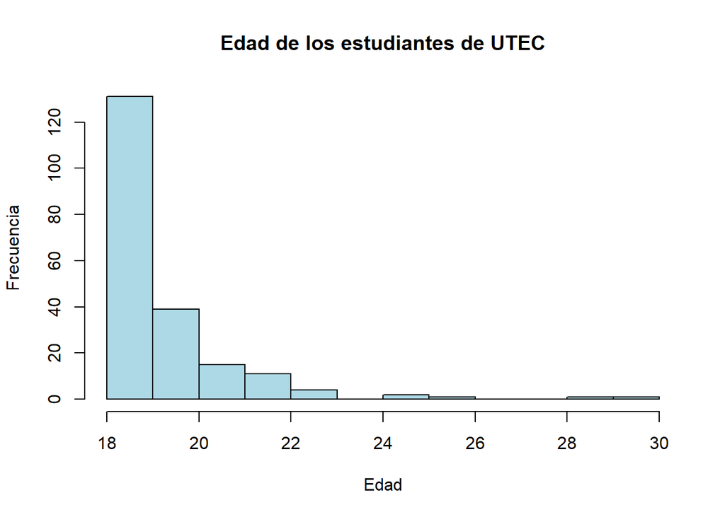

```r
hist(x = BD$Edad, main = "Edad de los estudiantes de UTEC", xlab = "Edad", ylab = "Frecuencia", col = "lightblue")
```

##### De este gráfico podemos mencionar que la mayor parte de encuestados tiene 18 o 19 años de edad y existe un sesgo a la derecha que es mayor a 0, es decir, la edad promedio de los estudiantes de UTEC encuestados es mayor que la mediana y la edad que presenta la mayoría de encuestados. Esto lo ampliaremos con el análisis de descriptores numéricos.

### **Descriptores numéricos:**

```r
cat('Número de observaciones:', nrow(BD),'\n')
```

```
## Número de observaciones: 205
```

```r
cat('Número de casos completos de la variable edad:', sum(complete.cases(BD$Edad)),'\n')
```

```
## Número de casos completos de la variable edad: 205
```

##### Vemos que el número de observaciones es 205 y el número de casos completos de la variable edad es el mismo, por lo que la muestra selectiva para el análisis de esta variable es 205 observaciones.

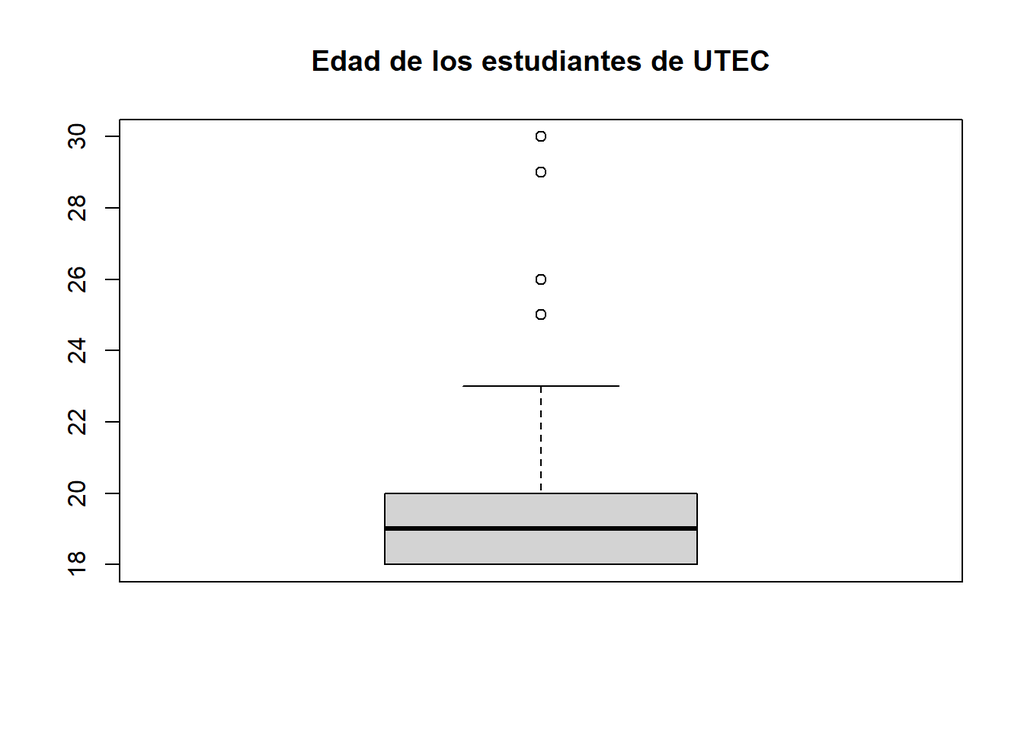

```r
boxplot(BD$Edad, main = "Edad de los estudiantes de UTEC")
```

##### Observamos que existen 4 datos atípicos, eso es viable porque se está trabajando con datos de estudiantes que si pueden llegar a tener las edades que tienen números atípicos, por lo que no lo eliminamos pero ya no determinaremos la media ya que no sería una medida adecuada:

```r
cat('Mediana de la variable edad:',round(median(BD$Edad, na.rm=TRUE),2),'\n')
```

```
## Mediana de la variable edad: 19
```

```r
cat('Moda de la variable edad:',18 ,'\n')
```

```
## Moda de la variable edad: 18
```

```r
cat('Varianza de la variable edad:',round(var(BD$Edad, na.rm=TRUE),2),'\n')
```

```
## Varianza de la variable edad: 3.25
```

```r
cat('Desviación estándar de la variable edad:',round(sd(BD$Edad, na.rm=TRUE),2),'\n')
```

```
## Desviación estándar de la variable edad: 1.8
```

```r
cat('Coeficiente de variación de la variable edad:', round((sd(BD$Edad, na.rm=TRUE)/mean(BD$Edad, na.rm=TRUE))*100,2),'\n')
```

```
## Coeficiente de variación de la variable edad: 9.31
```

##### A partir de lo realizado podemos mencionar que la mitad de los encuestados tiene una edad mayor o igual que 19 y la otra mitad, menor a este número. La mayor parte de encuestados tiene 18 años de edad. Asimismo, podemos ver que las edades no varían mucho respecto a su media, por lo que las edades de los estudiantes de UTEC tienden a estar agrupados cerca de su media. Además, el coeficiente de variación es 9.31 por lo que los datos son homogéneos. En resumen, se podría decir que los datos tienen poca variabilidad.

### - *Género*

### **Análisis univariado:**

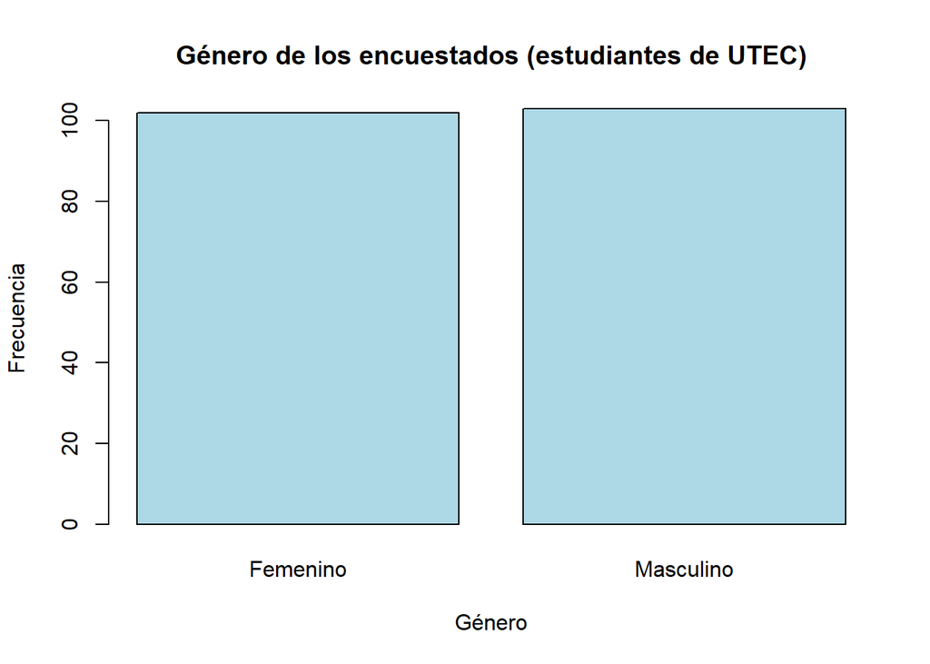

```r
TABLA<-table(BD$Género)
barplot(TABLA, main = "Género de los encuestados (estudiantes de UTEC)",
     xlab = "Género", ylab = "Frecuencia",
     col = c("lightblue"))
```

```r
table(BD$Género)
```

```
##
##  Femenino Masculino
##       102       103
```

##### De este gráfico de barras se evidencia que la muestra de estudio es significativa respecto al género ya que la diferencia entre el número de encuestados varones respecto a las mujeres es 1, por lo que no hay una diferencia considerable entre el género de encuestados de UTEC.

```r
cat('Número de observaciones:', nrow(BD),'\n')
```

```
## Número de observaciones: 205
```

```r
cat('Número de casos completos de la variable género:', sum(complete.cases(BD$Género)),'\n')
```

```
## Número de casos completos de la variable género: 205
```

##### El número de observaciones es 205 y el número de casos completos de la variable género es el mismo, por lo que la muestra selectiva para el análisis de esta variable es 205 observaciones.

```r
cat('Moda de la variable género:', "Masculino" ,'\n')
```

```
## Moda de la variable género: Masculino
```

##### La variable género es una variable cualitativa por lo que se determina que el género mas frecuente en el estudio es masculino, sin embargo, como se menciono a inicios la diferencia es 1 por lo que nuestra muestra es significativa respecto al género.

### **Análisis comparativo**

##### En esta variable se analizo el cambio de la alimentación de los estudiantes de UTEC durante el confinamiento según el género, donde se obtuvo los siguientes resultados:

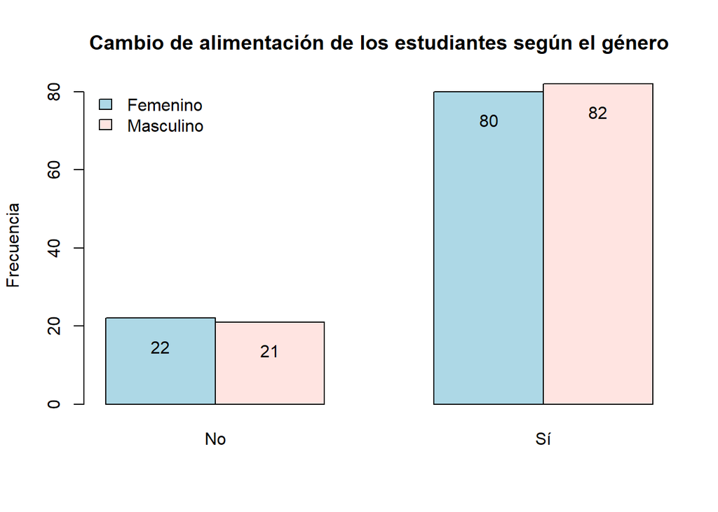

```r
a<-table(BD$Género,BD$`Percepción sobre el cambio de alimentación por el confinamiento`)
barp<-barplot(a,beside=TRUE,main = "Cambio de alimentación de los estudiantes según el género", xlab='', ylab='Frecuencia',col = c("lightblue", "mistyrose"))
text(barp, a-7.25, labels = a)
legend('topleft', legend=rownames(a), bty='n',
       fill=c("lightblue", "mistyrose"))
```

#### Podemos ver que tanto mujeres y varones, estudiantes de la Universidad de Ingeniería y Tecnología, cambiaron su alimentación sin alguna diferencia significativa entre ellas, por lo que no se menciona que en proporcion similar según el género hubo cambios en los hábitos de alimentación.

### - *Lugar de residencia*

### **Análisis univariado:**

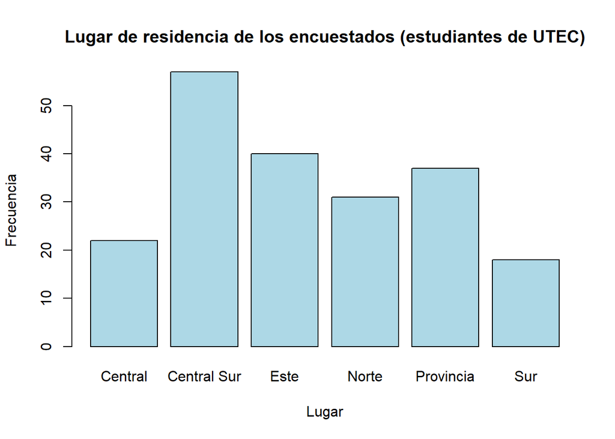

```r
TABLA<-table(BD$`Lugar de residencia`)
barplot(TABLA, main = "Lugar de residencia de los encuestados (estudiantes de UTEC)",
     xlab = "Lugar", ylab = "Frecuencia",
     col = c("lightblue"))
```

##### De este gráfico de barras se evidencia que hubieron mas encuestados de la zona Central Sur que está conformado por los distritos de Barranco, Miraflores, Surco, San Borja, Surquillo, San Isidro, Chorrillos. Luego de ellas se encuentra la zona este conformada por S. J. de Lurigancho, Sta. Anita, Cieneguilla, Ate Vitarte, La Molina, Chaclacayo, Lurigancho, El Agustino, mientras la zona que tuvo poca frecuencia fue la zona Sur (S. J. de Miraflores, V.M. de Triunfo, Villa el Salvador, Lúrin y Pachacamac).

```r
cat('Número de observaciones:', nrow(BD),'\n')
```

```
## Número de observaciones: 205
```

```r
cat('Número de casos completos de la variable lugar de residencia:', sum(complete.cases(BD$`Lugar de residencia`)),'\n')
```

```
## Número de casos completos de la variable lugar de residencia: 205
```

##### El número de observaciones es 205 y el número de casos completos de la variable género es el mismo, por lo que la muestra selectiva para el análisis de esta variable es 205 observaciones.

```r
cat('Moda de la variable lugar de residencia:', "Central Sur" ,'\n')
```

```
## Moda de la variable lugar de residencia: Central Sur
```

##### La variable lugar de residencia es cualitativa por lo que solamente determinamos la moda por medio de una tabla donde vemos que el lugar de residencia mas frecuente de los estudiantes de UTEC encuestados fue Central Sur que está conformado por Barranco, Miraflores, Surco, San Borja, Surquillo, San Isidro, Chorrillos.

### **Análisis comparativo**

##### Con esta variable se piensa evaluar la Influencia del lugar de residencia en el cambio de alimentación por el confinamiento de los estudiantes de la Universidad de Ingeniería y Tecnología, para ello se realizó el siguiente gráfico, partiendo de una tabla de contingencia:

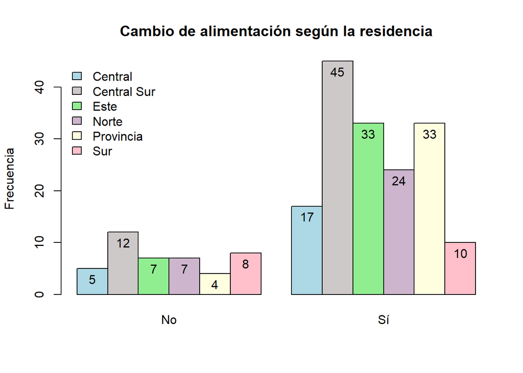

```r
b<-table(BD$`Lugar de residencia`,BD$`Percepción sobre el cambio de alimentación por el confinamiento`)
barp<-barplot(b,beside=TRUE,main = "Cambio de alimentación según la residencia", xlab='', ylab='Frecuencia',col = c("lightblue", "snow3","lightgreen","thistle3","lightyellow","pink"))
text(barp, b-2, labels = b)
legend('topleft', legend=rownames(b), bty='n',
       fill=c("lightblue", "snow3","lightgreen","thistle3","lightyellow","pink"))
```

##### Se puede observar que la gran parte de los estudiantes de UTEC que cambiaron su alimentación por el confinamiento viven en la zona Central Sur, es decir, en Barranco, Miraflores, Surco, San Borja, Surquillo, San Isidro, Chorrillos, a diferencia de los otros lugares.

### - *Peso antes del confinamiento:*

### **Análisis univariado:**

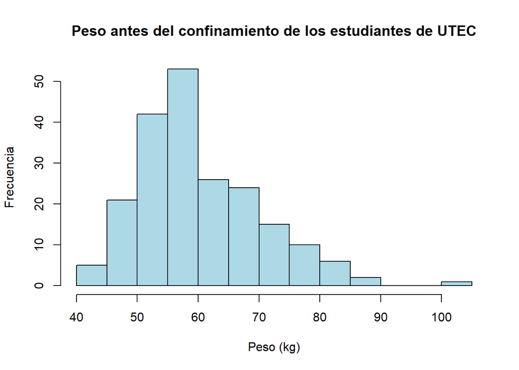

```r
hist(x = BD$`Peso antes del confinamiento`, main = "Peso antes del confinamiento de los estudiantes de UTEC", xlab = "Peso (kg)", ylab = "Frecuencia", col = "lightblue")
```

##### De este histograma podemos mencionar que la distribución del peso antes del confinamiento es asimétrica positiva, ya que el sesgo es mayor a 0 lo que indica que la media es mayor a la mediana y esta, a la moda. Además, se puede visualizar que la mayor parte de las personas tiene un peso en el intervalo de 50 - 60.

### **Descriptores numéricos:**

```r
cat('Número de observaciones de la variable peso antes del confinamiento:', nrow(BD),'\n')
```

```
## Número de observaciones de la variable peso antes del confinamiento: 205
```

```r
cat('Número de casos completos de la variable peso antes del confinamiento:', sum(complete.cases(BD$`Peso antes del confinamiento`)),'\n')
```

```
## Número de casos completos de la variable peso antes del confinamiento: 205
```

##### El número de observaciones es 205 y el número de casos completos de la variable peso antes del confinamiento es el mismo, por lo que la muestra selectiva para el análisis de esta variable es 205 observaciones.

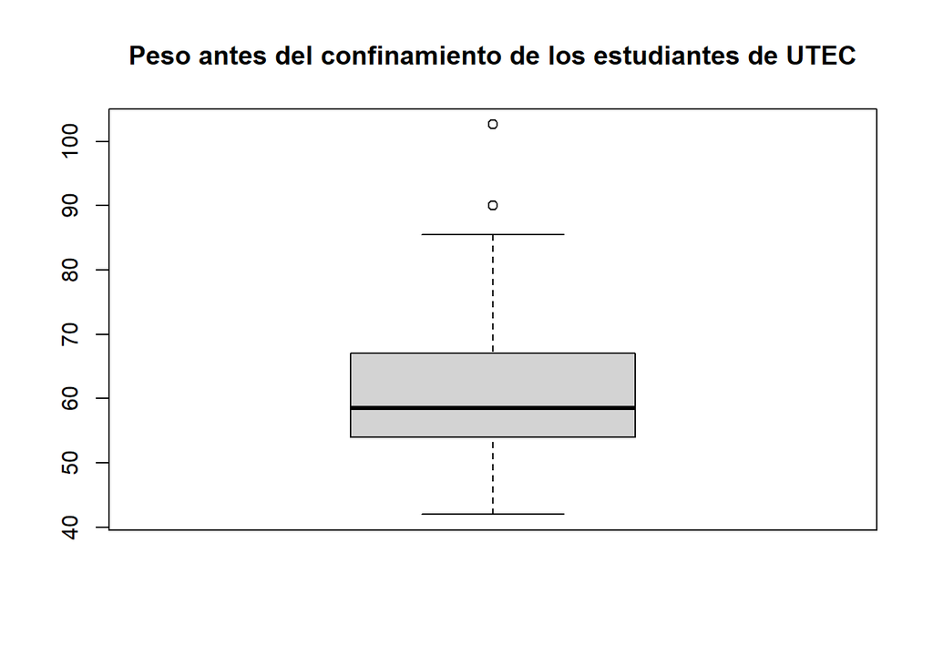

```r
boxplot(BD$`Peso antes del confinamiento`, main = "Peso antes del confinamiento de los estudiantes de UTEC")
```

##### Observamos que existen 2 datos atípicos, es fáctible ya que pueden existir personas que tienen ese valor de peso, por lo que se trabajará con el total de la muestra, pero no se puede analizar la media de esta variable:

```r
cat('Mediana de la variable peso antes del confinamiento:',round(median(BD$`Peso antes del confinamiento`, na.rm=TRUE),2),'\n')
```

```
## Mediana de la variable peso antes del confinamiento: 58.5
```

```r
cat('Moda de la variable peso antes del confinamiento:',55 ,'\n')
```

```
## Moda de la variable peso antes del confinamiento: 55
```

```r
cat('Varianza de la variable peso antes del confinamiento:',round(var(BD$`Peso antes del confinamiento`, na.rm=TRUE),2),'\n')
```

```
## Varianza de la variable peso antes del confinamiento: 98.27
```

```r
cat('Desviación estándar de la variable peso antes del confinamiento:',round(sd(BD$`Peso antes del confinamiento`, na.rm=TRUE),2),'\n')
```

```
## Desviación estándar de la variable peso antes del confinamiento: 9.91
```

```r
cat('Coeficiente de variación de la variable peso antes del confinamiento:', round((sd(BD$`Peso antes del confinamiento`, na.rm=TRUE)/mean(BD$Edad, na.rm=TRUE))*100,2),'\n')
```

```
## Coeficiente de variación de la variable peso antes del confinamiento: 51.22
```

### **Análisis comparativo**

##### En las variables peso y talla se realizaron dos modelos linelaes que relacionen el peso con la talla antes y después del confinamiento, obteniendose la ecuación. Asimismo, se empleo diversos descriptores numéricos para analizar la variable peso: La ecuación que representa el peso en función de la talla antes del confinamiento es: y=72.504x - 57.246

```r
Peso<-BD$`Peso antes del confinamiento`
Estatura<-BD$`Estatura antes del confinamiento`
modelo<-lm(Peso~Estatura)
summary(modelo)
```

```
##
## Call:
## lm(formula = Peso ~ Estatura)
##
## Residuals:
##     Min      1Q  Median      3Q     Max
## -17.486  -5.585  -0.410   4.064  32.964
##
## Coefficients:
##             Estimate Std. Error t value Pr(>|t|)
## (Intercept)  -57.246     11.251  -5.088 8.21e-07 ***
## Estatura      72.504      6.896  10.513  < 2e-16 ***
## ---
## Signif. codes:  0 '***' 0.001 '**' 0.01 '*' 0.05 '.' 0.1 ' ' 1
##
## Residual standard error: 7.996 on 203 degrees of freedom
## Multiple R-squared:  0.3525, Adjusted R-squared:  0.3493
## F-statistic: 110.5 on 1 and 203 DF,  p-value: < 2.2e-16
```

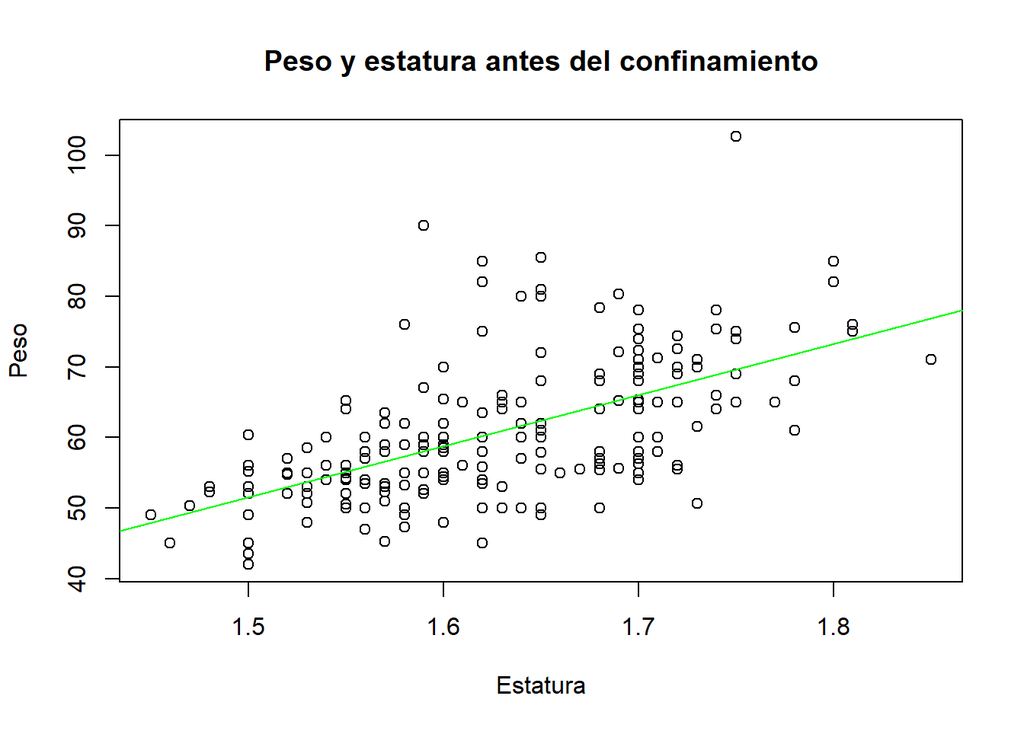

```r
plot(Estatura,Peso)
title(main = "Peso y estatura antes del confinamiento")
abline(modelo,col="green")
```

### - *Peso después del confinamiento:*

### **Análisis univariado:**

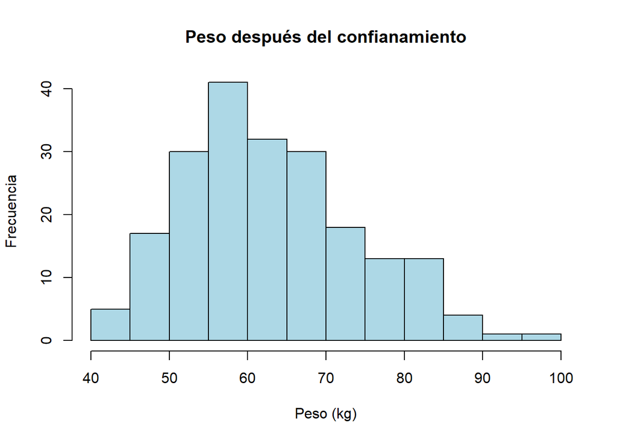

```r
hist(x = BD$`Peso después del confinamiento`, main = "Peso después del confianamiento", xlab = "Peso (kg)", ylab = "Frecuencia", col = "lightblue")
```

### **Descriptores numéricos:**

```r
cat('Número de observaciones:', nrow(BD),'\n')
```

```
## Número de observaciones: 205
```

```r
cat('Número de casos completos de la variable peso después del confinamiento:', sum(complete.cases(BD$`Peso después del confinamiento`)),'\n')
```

```
## Número de casos completos de la variable peso después del confinamiento: 205
```

##### El número de observaciones es 205 y el número de casos completos de la variable peso después del confinamiento es el mismo, por lo que la muestra selectiva para el análisis de esta variable es 205 observaciones.

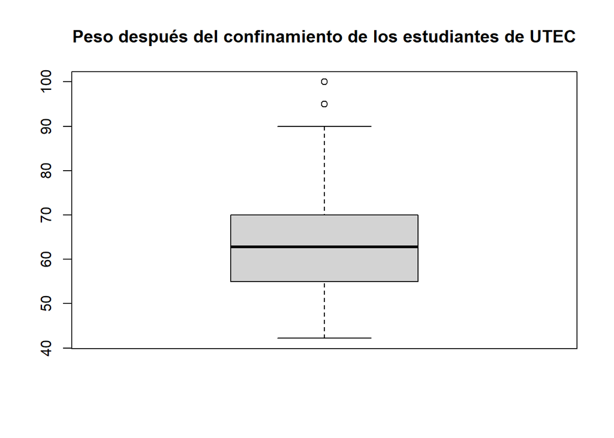

```r
boxplot(BD$`Peso después del confinamiento`, main = "Peso después del confinamiento de los estudiantes de UTEC")
```

##### Observamos que existen 2 datos atípicos, es correcto puesto que los estudiantes de UTEC pueden tener ese peso; sin embargo, por la existencia de datos atípicos ya no analizamos la media aritmética de esta variable.

```r
table(BD$`Peso después del confinamiento`)
```

```
##
##  42.2  43.5    44    45    46    47    48    49    50  50.2    51    52  52.1
##     1     1     2     1     2     1     3     3     8     1     3     4     1
##  52.3  52.5    53  53.6    54  54.2  54.8    55  55.3  55.4  55.5  55.6  55.7
##     2     1     5     1     4     1     2     5     1     1     1     2     1
##  55.8    56    57  57.2    58  58.2  58.5  58.7    59  59.4  59.5    60    61
##     1     8     2     1     9     1     1     1     6     1     1     3     4
##  61.5    62  62.5  62.8    63  63.3    64    65  65.4  65.5    66  66.4    67
##     1     3     1     1     8     1     6     7     1     1     4     1     7
##  67.5  67.8    68    69    70    71  71.2 71.65    72    73  73.2  73.8    75
##     1     1     3     4     7     4     1     1     3     1     1     3     4
##    76  76.3  77.4    78  78.4  78.5 78.85    80  80.2    81  81.6  82.1    83
##     1     1     1     2     1     1     1     5     1     1     1     1     2
##    84  84.8    85    88    89  89.2    90    95   100
##     3     1     3     1     1     1     1     1     1
```

```r
cat('Mediana de la variable peso después del confinamiento:',round(median(BD$`Peso después del confinamiento`, na.rm=TRUE),2),'\n')
```

```
## Mediana de la variable peso después del confinamiento: 62.8
```

```r
cat('Moda de la variable peso después del confinamiento:',58 ,'\n')
```

```
## Moda de la variable peso después del confinamiento: 58
```

```r
cat('Varianza de la variable peso después del confinamiento:',round(var(BD$`Peso después del confinamiento`, na.rm=TRUE),2),'\n')
```

```
## Varianza de la variable peso después del confinamiento: 126.58
```

```r
cat('Desviación estándar de la variable peso después del confinamiento:',round(sd(BD$`Peso después del confinamiento`, na.rm=TRUE),2),'\n')
```

```
## Desviación estándar de la variable peso después del confinamiento: 11.25
```

```r
cat('Coeficiente de variación de la variable peso después del confinamiento:', round((sd(BD$`Peso después del confinamiento`, na.rm=TRUE)/mean(BD$Edad, na.rm=TRUE))*100,2),'\n')
```

```
## Coeficiente de variación de la variable peso después del confinamiento: 58.12
```

### **Análisis comparativo**

##### Como se mencionó anteriormente en las variables peso y talla se realizaron dos modelos linelaes que relacionen el peso con la talla antes y después del confinamiento, obteniendose una ecuación que modele la relación entre ellos. La ecuación que representa el peso en función de la talla después del confinamiento es: y=78.360x - 65.151

```r
Peso<-BD$`Peso después del confinamiento`
Estatura<-BD$`Estatura después del confinamiento`
modelo<-lm(Peso~Estatura)
summary(modelo)
```

```
##
## Call:
## lm(formula = Peso ~ Estatura)
##
## Residuals:
##      Min       1Q   Median       3Q      Max
## -21.5128  -6.3065   0.1263   4.2083  27.2380
##
## Coefficients:
##             Estimate Std. Error t value Pr(>|t|)
## (Intercept)  -65.151     10.604  -6.144 4.19e-09 ***
## Estatura      78.360      6.447  12.155  < 2e-16 ***
## ---
## Signif. codes:  0 '***' 0.001 '**' 0.01 '*' 0.05 '.' 0.1 ' ' 1
##
## Residual standard error: 8.58 on 203 degrees of freedom
## Multiple R-squared:  0.4212, Adjusted R-squared:  0.4184
## F-statistic: 147.7 on 1 and 203 DF,  p-value: < 2.2e-16
```

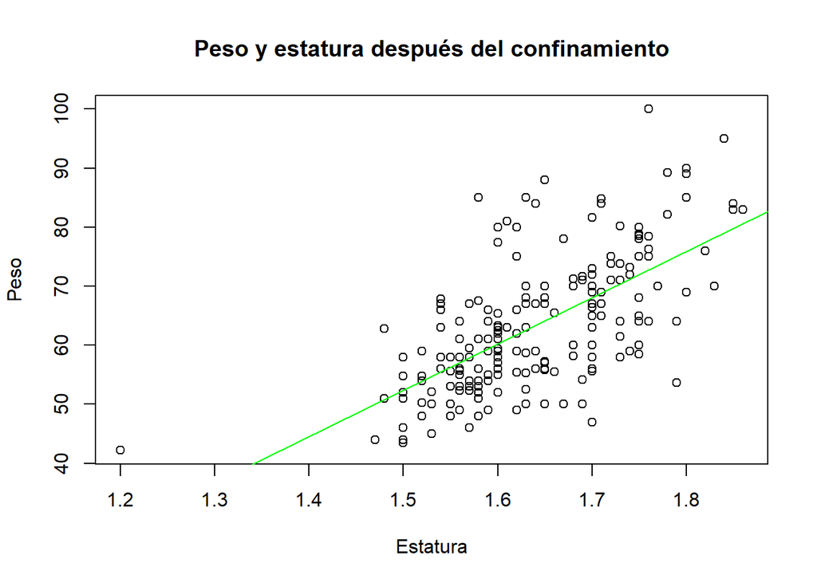

```r
plot(Estatura,Peso)
abline(modelo,col="green")
title(main = "Peso y estatura después del confinamiento")
```

### - *Estatura antes del confinamiento:*

### **Análisis univariado:**

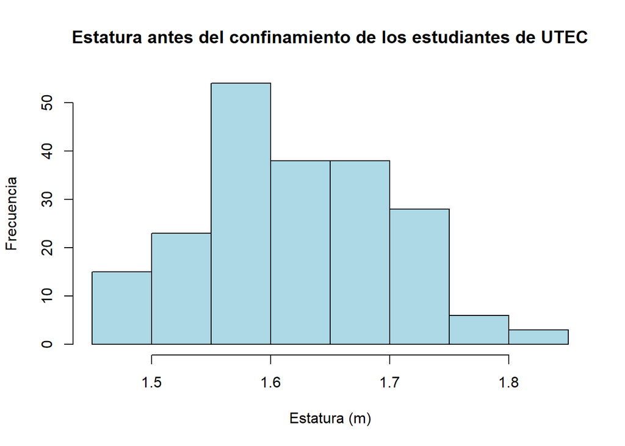

```r
hist(x = BD$`Estatura antes del confinamiento`, main = "Estatura antes del confinamiento de los estudiantes de UTEC", xlab = "Estatura (m)", ylab = "Frecuencia", col = "lightblue")
```

### **Descriptores numéricos:**

```r
cat('Número de observaciones:', nrow(BD),'\n')
```

```
## Número de observaciones: 205
```

```r
cat('Número de casos completos de la variable estatura antes del confinamiento:', sum(complete.cases(BD$`Estatura antes del confinamiento`)),'\n')
```

```
## Número de casos completos de la variable estatura antes del confinamiento: 205
```

##### El número de observaciones es 205 y el número de casos completos de la variable estatura antes del confinamiento es el mismo, por lo que la muestra selectiva para el análisis de esta variable es 205 observaciones.

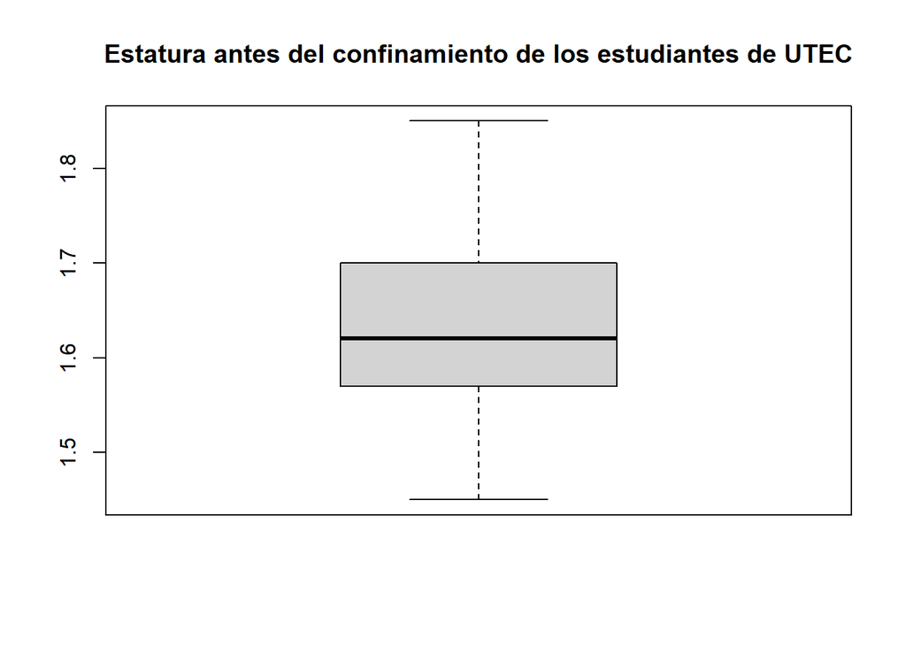

```r
boxplot(BD$`Estatura antes del confinamiento`, main = "Estatura antes del confinamiento de los estudiantes de UTEC")
```

##### Observamos que no existen datos atípicos, por lo que en los descriptores numéricos podemos considerar a la media.

```r
table(BD$`Estatura antes del confinamiento`)
```

```
##
## 1.45 1.46 1.47 1.48  1.5 1.52 1.53 1.54 1.55 1.56 1.57 1.58 1.59  1.6 1.61 1.62
##    1    1    1    2   10    4    6    4    9   13    9   10    8   14    3   11
## 1.63 1.64 1.65 1.66 1.67 1.68 1.69  1.7 1.71 1.72 1.73 1.74 1.75 1.77 1.78  1.8
##    5    6   13    1    1   11    4   21    4    8    6    4    6    1    3    2
## 1.81 1.85
##    2    1
```

```r
cat('Mediana de la variable estatura antes del confinamiento:',round(median(BD$`Estatura antes del confinamiento`,na.rm=TRUE),2),'\n')
```

```
## Mediana de la variable estatura antes del confinamiento: 1.62
```

```r
cat('Media de la variable estatura antes del confinamiento:',round(mean(BD$`Estatura antes del confinamiento`, na.rm=TRUE),2),'\n')
```

```
## Media de la variable estatura antes del confinamiento: 1.63
```

```r
cat('Moda de la variable estatura antes del confinamiento:',1.7 ,'\n')
```

```
## Moda de la variable estatura antes del confinamiento: 1.7
```

```r
cat('Varianza de la variable estatura antes del confinamiento:',round(var(BD$`Estatura antes del confinamiento`, na.rm=TRUE),2),'\n')
```

```
## Varianza de la variable estatura antes del confinamiento: 0.01
```

```r
cat('Desviación estándar de la variable estatura antes del confinamiento:',round(sd(BD$`Estatura antes del confinamiento`, na.rm=TRUE),2),'\n')
```

```
## Desviación estándar de la variable estatura antes del confinamiento: 0.08
```

```r
cat('Coeficiente de variación de la variable estatura antes del confinamiento:', round((sd(BD$`Estatura antes del confinamiento`, na.rm=TRUE)/mean(BD$Edad, na.rm=TRUE))*100,2),'\n')
```

```
## Coeficiente de variación de la variable estatura antes del confinamiento: 0.42
```

### - *Estatura después del confinamiento:*

### **Análisis univariado:**

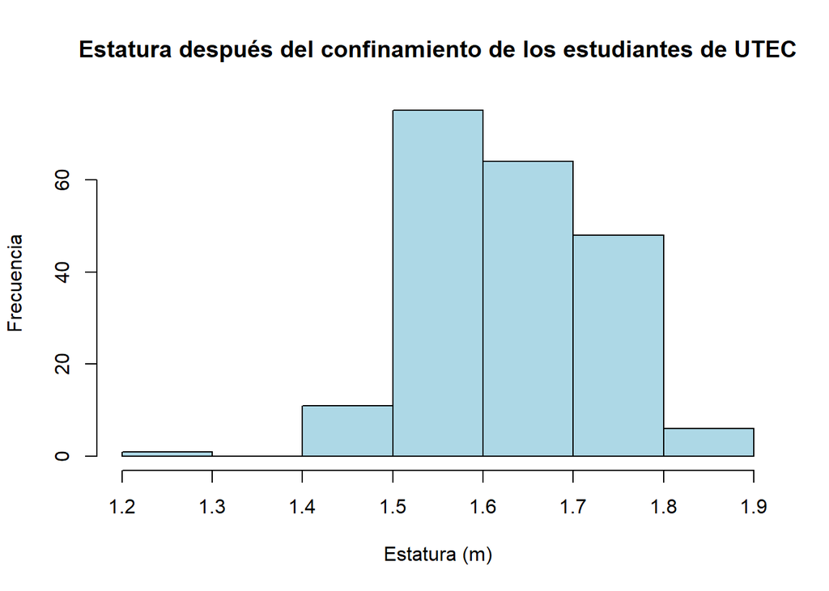

```r
hist(x = BD$`Estatura después del confinamiento`, main = "Estatura después del confinamiento de los estudiantes de UTEC", xlab = "Estatura (m)", ylab = "Frecuencia", col = "lightblue")
```

### **Descriptores numéricos:**

```r
cat('Número de observaciones:', nrow(BD),'\n')
```

```
## Número de observaciones: 205
```

```r
cat('Número de casos completos de la variable estatura después del confinamiento:', sum(complete.cases(BD$`Estatura después del confinamiento`)),'\n')
```

```
## Número de casos completos de la variable estatura después del confinamiento: 205
```

##### El número de observaciones es 205 y el número de casos completos de la variable estatura después del confinamiento es el mismo, por lo que la muestra selectiva para el análisis de esta variable es 205 observaciones.

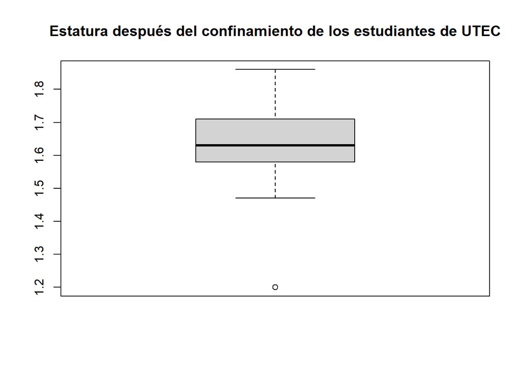

```r
boxplot(BD$`Estatura después del confinamiento`, main = "Estatura después del confinamiento de los estudiantes de UTEC")
```

##### Observamos que existe un datos atípico, por lo que no podemos determinar la media aritmetica.

```r
cat('Mediana de la variable estatura después del confinamiento:',round(median(BD$`Estatura después del confinamiento`,na.rm=TRUE),2),'\n')
```

```
## Mediana de la variable estatura después del confinamiento: 1.63
```

```r
cat('Moda de la variable estatura después del confinamiento:',1.6 ,'\n')
```

```
## Moda de la variable estatura después del confinamiento: 1.6
```

```r
cat('Varianza de la variable estatura después del confinamiento:',round(var(BD$`Estatura después del confinamiento`, na.rm=TRUE),2),'\n')
```

```
## Varianza de la variable estatura después del confinamiento: 0.01
```

```r
cat('Desviación estándar de la variable estatura después del confinamiento:',round(sd(BD$`Estatura después del confinamiento`, na.rm=TRUE),2),'\n')
```

```
## Desviación estándar de la variable estatura después del confinamiento: 0.09
```

```r
cat('Coeficiente de variación de la variable estatura después del confinamiento:', round((sd(BD$`Estatura después del confinamiento`, na.rm=TRUE)/mean(BD$Edad, na.rm=TRUE))*100,2),'\n')
```

```
## Coeficiente de variación de la variable estatura después del confinamiento: 0.48
```

##### De lo determinado podemos mencionar que la estatura después del confinamiento que aparece con mayor frecuencia en nuestro conjunto de datos es 1.6. Además, a partir de lo realizado podemos mencionar que el valor intermedio de nuestra variable es 1.63, es decir la mitad de los encuestados tuvo una estatura mayor o igual a 1.63 y la otra mitad, menor a este número. Asimismo, el coeficente de variación es muy pequeño por lo que los datos obtenidos respecto a esta variable son homogéneos y no existe mucha variabilidad entre ellos.

### **Análisis comparativo**

##### Respecto a esta variable se determino la comparación de los cambios del IMC antes y después del confinamiento de los estudiantes de la Universidad de Ingeniería y Tecnología, donde se obtuvo el siguiente resultado a través de un grafico de dispersión:

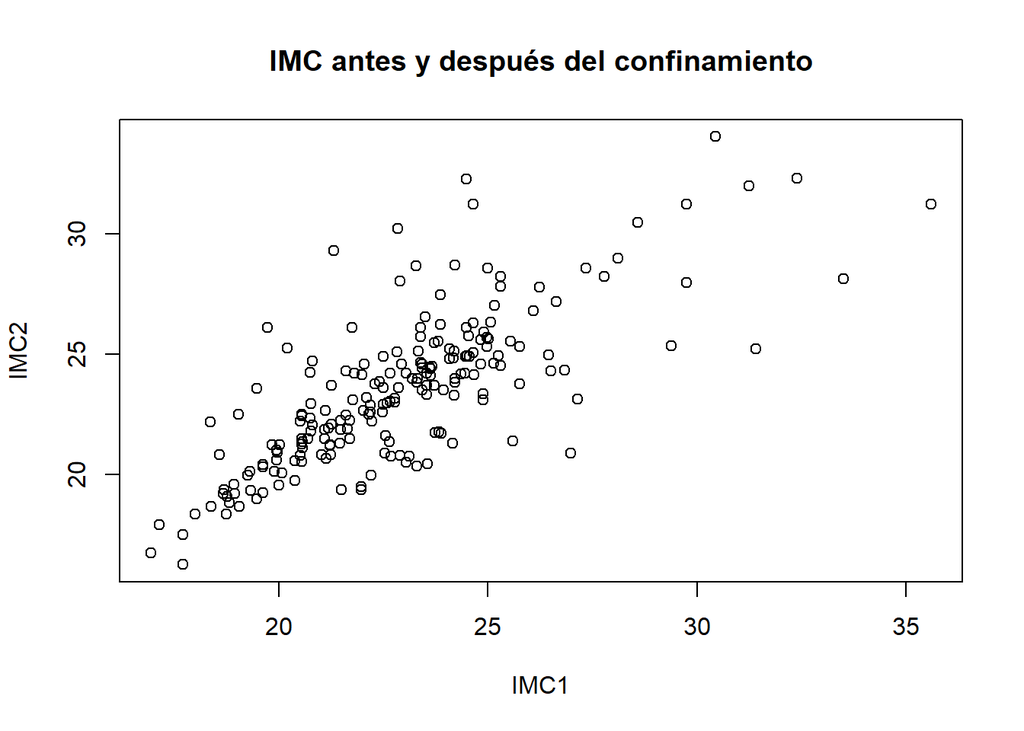

```r
IMC1 <- BD$`Peso antes del confinamiento`/(BD$`Estatura antes del confinamiento`*BD$`Estatura antes del confinamiento`)
IMC2 <- BD$`Peso después del confinamiento`/(BD$`Estatura después del confinamiento`*BD$`Estatura después del confinamiento`)
plot(IMC1, IMC2)
title(main = "IMC antes y después del confinamiento")
```

##### El gráfico de dispersión comparativo del IMC de los estudiantes nos indica que existe una correlación proporcional. Pero podemos identificar que, el “IMC” después del confinamiento (IMC2), presenta una mayor cantidad de datos mas dispersos, es decir que en el periodo después del confinamiento hubo unos cambios mas significativos en el índice de masa corporal. Específicamente en el aumento del “IMC”, en comparación del periodo antes del confinamiento (IMC1).

### - *Convivencia durante el confinamiento*

### **Análisis univariado:**

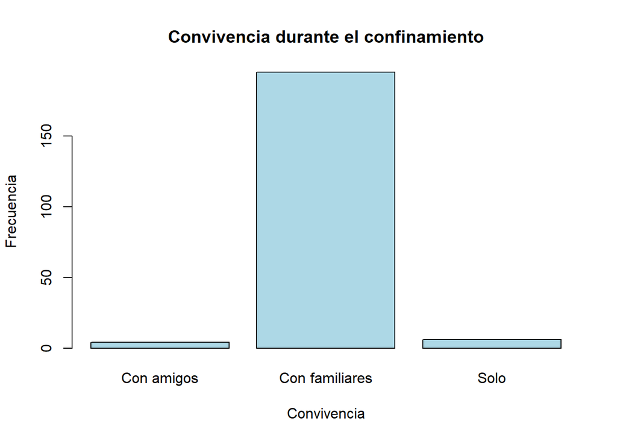

```r
TABLA<-table(BD$`Convivencia durante el confinamiento`)
barplot(TABLA, main = "Convivencia durante el confinamiento",
     xlab = "Convivencia", ylab = "Frecuencia",
     col = c("lightblue"))
```

```r
table(BD$`Convivencia durante el confinamiento`)
```

```
##
##     Con amigos Con familiares           Solo
##              4            195              6
```

##### De este gráfico de barras podemos afirmar que los estudiantes de UTEC convivieron durante la pandemia con su familia y otros encuestados, en pequeña proporción, solos y/o con amigos.

```r
cat('Número de observaciones:', nrow(BD),'\n')
```

```
## Número de observaciones: 205
```

```r
cat('Número de casos completos de la variable de convivencia durante el confinamiento:', sum(complete.cases(BD$`Convivencia durante el confinamiento`)),'\n')
```

```
## Número de casos completos de la variable de convivencia durante el confinamiento: 205
```

##### El número de observaciones es 205 y el número de casos completos de la variable de convivencia durante el confinamiento, por lo que la muestra selectiva para el análisis de esta variable es 205 observaciones.

```r
cat('Moda de la variable de convivencia durante el confinamiento:', "Con familiares" ,'\n')
```

```
## Moda de la variable de convivencia durante el confinamiento: Con familiares
```

##### Esta variable es de tipo cualitativa por lo que se determina la moda obteniendose que los estudiantes de UTEC en su mayoría vivieron con sus familiares durante el confinamiento.

### **Análisis comparativo**

#### En esta variable se analizó la influencia de las personas con las que se convivió durante el confinamiento en el cambio de alimentación de los estudiantes de la Universidad de Ingeniería y Tecnología, para ello partimos de una tabla de contingencia y lo organizamos en un gráfico de barras:

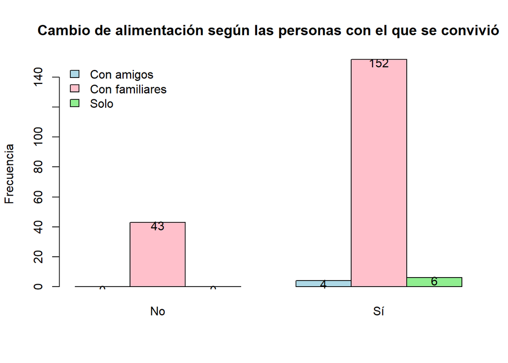

```r
b<-table(BD$`Convivencia durante el confinamiento`, BD$`Percepción sobre el cambio de alimentación por el confinamiento`)
barp<-barplot(b,beside=TRUE,main = "Cambio de alimentación según las personas con el que se convivió", xlab='', ylab='Frecuencia',col = c("lightblue","pink", "lightgreen"))
text(barp, b-2, labels = b)
legend('topleft', legend=rownames(b), bty='n',
       fill=c("lightblue","pink", "lightgreen"))
```

### - *Sentimientos durante el confinamiento*

### **Análisis univariado:**

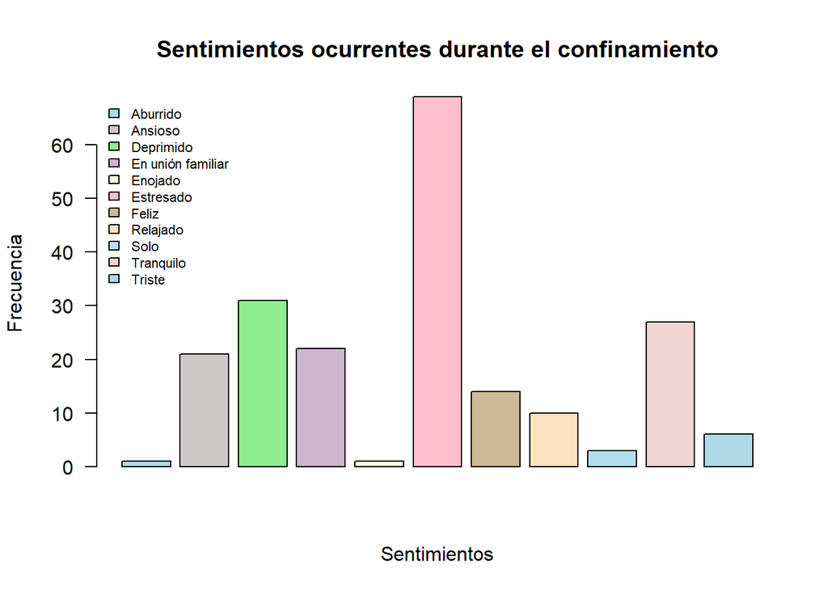

```r
TABLA<-table(BD$`Sentimientos durante el confinamiento`)
barplot(TABLA, main = "Sentimientos ocurrentes durante el confinamiento",xaxt = "n",
     xlab = "Sentimientos", ylab = "Frecuencia",
     col = c("lightblue", "snow3","lightgreen","thistle3","lightyellow","pink","wheat3", "bisque","lightblue2","mistyrose2"),las=2,cex.names = 0.45)
legend('topleft', legend=rownames(TABLA), bty='n',
       fill=c("lightblue", "snow3","lightgreen","thistle3","lightyellow","pink","wheat3", "bisque","lightblue2","mistyrose2"),cex=0.7)
```

##### A partir de este gráfico de barras podemos determinar que gran parte de los estudiantes de UTEC se sintió estresado durante el confinamiento, otro factor que sobresale pero no llega a alcanzar la frecuencia de estrés es la depresión, podemos decir que el sentimiento que prevaleció durante el confinamiento fue el estrés que probablemente haya generado cambios en la alimentación de los estudiantes de UTEC, esto lo veremos en el desarrollo de este trabajo.

```r
cat('Número de observaciones de la variable sentimientos durante el confinamiento:', nrow(BD),'\n')
```

```
## Número de observaciones de la variable sentimientos durante el confinamiento: 205
```

```r
cat('Número de casos completos de la variable sentimientos durante el confinamiento:', sum(complete.cases(BD$`Sentimientos durante el confinamiento`)),'\n')
```

```
## Número de casos completos de la variable sentimientos durante el confinamiento: 205
```

##### El número de observaciones es 205 y el número de casos completos de la variable sentimientos durante el confinamiento, por lo que la muestra selectiva para el análisis de esta variable es 205 observaciones.

```r
cat('Moda de la variable sentimientos durante el confinamiento', "Estresado" ,'\n')
```

```
## Moda de la variable sentimientos durante el confinamiento Estresado
```

##### Como es una variable cualitiva se debe determinar la moda, donde se obtiene el sentimiento “estresado”, esto indica que el sentimiento que se repitió con mayor frecuencia durante el confinamiento fue el estrés, ampliaremos mas este análisis con el resto de variables.

### **Análisis comparativo**

##### En esta variable se analizo el impacto de los sentimientos en la alimentación de los estudiantes de UTEC durante el confinamiento, donde se obtuvo los siguientes resultados a partir de una tabla de contingencia:

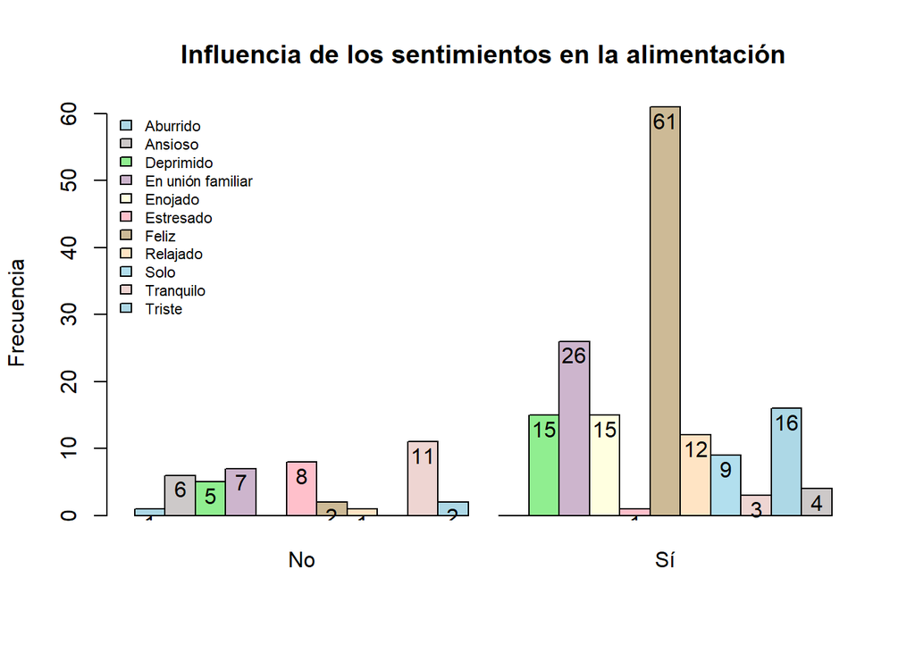

```r
b<-table(BD$`Sentimientos durante el confinamiento`,BD$`Percepción sobre el cambio de alimentación por el confinamiento`)
barp<-barplot(b,beside=TRUE,main = "Influencia de los sentimientos en la alimentación", xlab='', ylab='Frecuencia',col = c("lightblue", "snow3","lightgreen","thistle3","lightyellow","pink","wheat3", "bisque","lightblue2","mistyrose2"))
text(barp, b-2, labels = b)
legend('topleft', legend=rownames(b), bty='n',
       fill=c("lightblue", "snow3","lightgreen","thistle3","lightyellow","pink","wheat3", "bisque","lightblue2","mistyrose2"),cex=0.7)
```

##### De este gráfico se determina que las personas que se sintieron estresadas cambiaron de manera significativa su alimentación que las otras, por lo que se podría decir que el factor psicológico influyó en los cambios de alimentación, principalmente el estrés.

### - *Consumo de frutas y verduras durante el confinamiento:*

### **Análisis univariado:**

##### En esta variable se analizo el impacto durante el confinamiento en la frecuencia del consumo de frutas y verduras en los estudiantes de UTEC, a continuación se analiza la frecuencia donde se obtuvo los siguientes resultados:

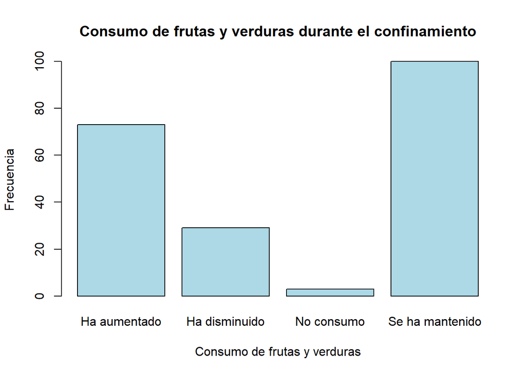

```r
counts <- table(BD$`Consumo de frutas y verduras durante el confinamiento`)
barplot(counts, main="Consumo de frutas y verduras durante el confinamiento", xlab = "Consumo de frutas y verduras", ylab = "Frecuencia",
        col=c("light blue"))
```

##### De este grafico podemos afirmar que durante el periodo de confinamiento, la mayoria de los alumnos de la Universidad de Ingenieria y Tecnologia ha mantenido la misma frecuencia del consumo de frutas y verduras en su alimentacion. Seguidamente de un considerable grupo de alumnos que aumentaron el consumo de estos productos.

```r
cat('Número de observaciones:', nrow(BD),'\n')
```

```
## Número de observaciones: 205
```

```r
cat('Número de casos completos de la variable de consumo de frutas y verduras durante el confinamiento:', sum(complete.cases(BD$`Consumo de frutas y verduras durante el confinamiento`)),'\n')
```

```
## Número de casos completos de la variable de consumo de frutas y verduras durante el confinamiento: 205
```

##### El número de observaciones y el numero de casos completos para la variable del consumo de frutas y verduras es 205, por lo que la muestra selectiva para el análisis de esta variable es 205 observaciones.

```r
cat('Moda de la variable de consumo de frutas y verduras durante el confinamiento:', "Se ha mantenido" ,'\n')
```

```
## Moda de la variable de consumo de frutas y verduras durante el confinamiento: Se ha mantenido
```

##### Esta variable es de tipo cualitativa por lo que se determina la moda obteniendose que los estudiantes de UTEC en su mayoría ha mantenido el consumo de frutas y verduras.

### - *Consumo de carnes rojas durante el confinamiento:*

### **Análisis univariado:**

#### En esta variable se analizo el impacto durante el confinamiento en la frecuencia del consumo de carnes rojas en los estudiantes de UTEC, a continuación se analiza la frecuencia donde se obtuvo los siguientes resultados:

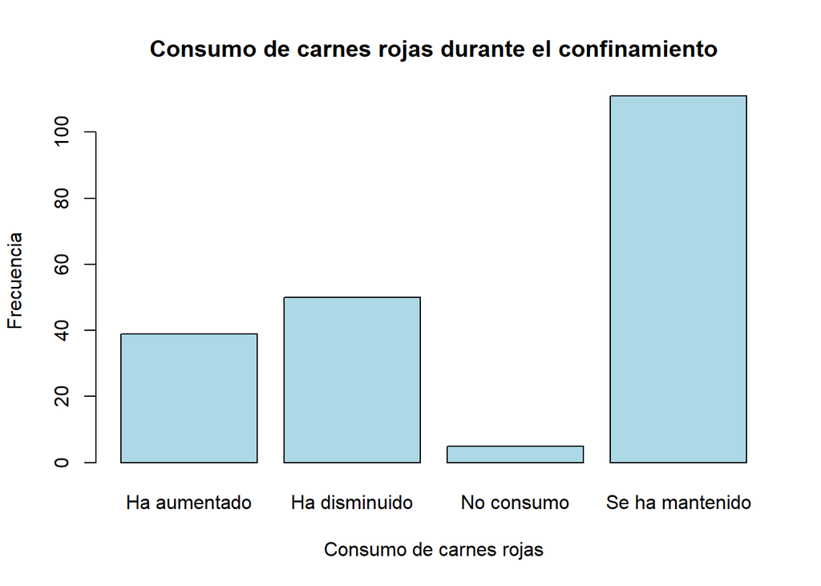

```r
counts <- table(BD$`Consumo de carnes rojas durante el confinamiento`)
barplot(counts, main="Consumo de carnes rojas durante el confinamiento",xlab = "Consumo de carnes rojas", ylab = "Frecuencia",
        col=c("light blue"))
```

```r
cat('Número de observaciones:', nrow(BD),'\n')
```

```
## Número de observaciones: 205
```

```r
cat('Número de casos completos de la variable  consumo de carnes rojas durante el confinamiento:', sum(complete.cases(BD$`Consumo de carnes rojas durante el confinamiento`)),'\n')
```

```
## Número de casos completos de la variable  consumo de carnes rojas durante el confinamiento: 205
```

##### El número de observaciones y el numero de casos completos para la variable del consumo de carnes rojas es 205, por lo que la muestra selectiva para el análisis de esta variable es 205 observaciones.

```r
cat('Moda de la variable de consumo de carnes rojas:', "Se ha mantenido" ,'\n')
```

```
## Moda de la variable de consumo de carnes rojas: Se ha mantenido
```

##### Esta variable es de tipo cualitativa por lo que se determina la moda obteniendose que los estudiantes de UTEC en su mayoría ha mantenido el consumo de carnes rojas.

### - *Consumo de carnes blancas durante el confinamiento:*

### **Análisis univariado:**

##### En esta variable se analizo el impacto durante el confinamiento en la frecuencia del consumo de carnes blancas en los estudiantes de UTEC, a continuación se analiza la frecuencia donde se obtuvo los siguientes resultados:

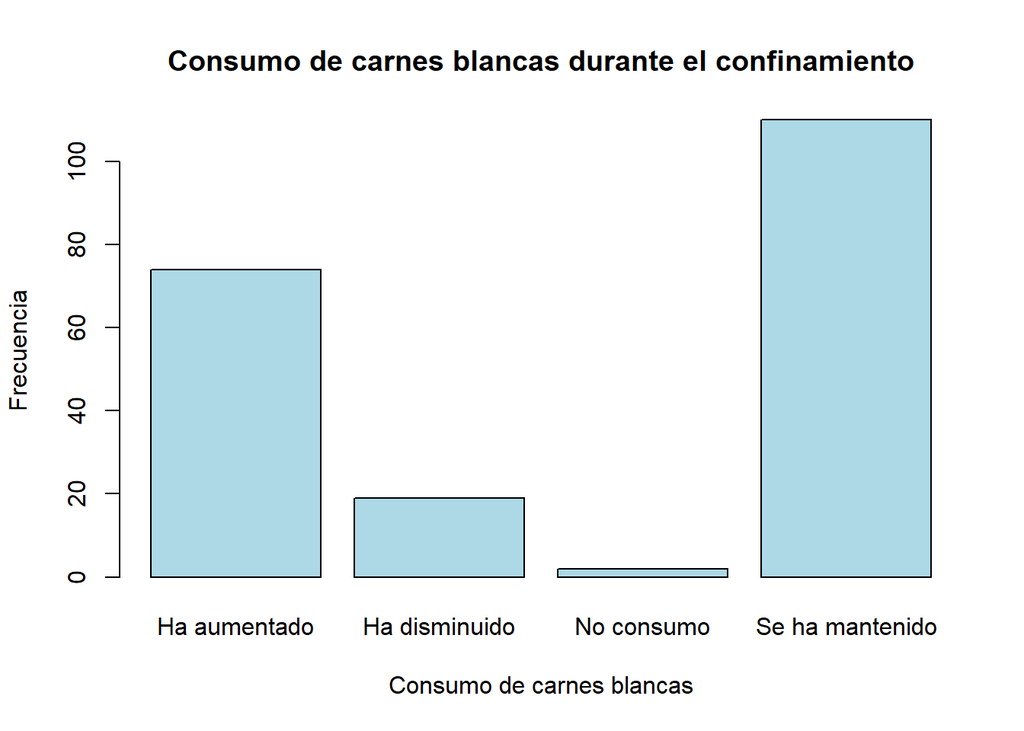

```r
counts <- table(BD$`Consumo de carnes blancas durante el confinamiento`)
barplot(counts, main="Consumo de carnes blancas durante el confinamiento", xlab = "Consumo de carnes blancas", ylab = "Frecuencia",
        col=c("light blue"))
```

##### De este grafico podemos afirmar que durante el periodo de confinamiento los alumnos de la Universidad de Ingenieria y Tecnologia han mantenido el consumo de carnes blancas en su alimentacion por lo que el confinamiento por el COVID-19 no impacto significativamente en ese sector de su alimentación pese a que un grupo considerable que aumentaron el consumo del producto.

```r
cat('Número de observaciones:', nrow(BD),'\n')
```

```
## Número de observaciones: 205
```

```r
cat('Número de casos completos de la variable  consumo de carnes blancas durante el confinamiento:', sum(complete.cases(BD$`Consumo de carnes blancas durante el confinamiento`)),'\n')
```

```
## Número de casos completos de la variable  consumo de carnes blancas durante el confinamiento: 205
```

##### El número de observaciones y el numero de casos completos para la variable del consumo de carnes blancas es 205, por lo que la muestra selectiva para el análisis de esta variable es 205 observaciones.

```r
cat('Moda de la variable consumo de carnes blancas durante el confinamiento:', "Se ha mantenido" ,'\n')
```

```
## Moda de la variable consumo de carnes blancas durante el confinamiento: Se ha mantenido
```

##### Esta variable es de tipo cualitativa por lo que se determina la moda obteniendose que los estudiantes de UTEC en su mayoría ha mantenido el consumo de carnes blancas por lo que el confinamiento por el COVID-19 no influyó en ese sector de su alimentación.

### - *Consumo de huevos durante el confinamiento:*

### **Análisis univariado:**

##### En esta variable se analizo el impacto durante el confinamiento en la frecuencia del consumo de huevos en los estudiantes de UTEC, a continuación se analiza la frecuencia donde se obtuvo los siguientes resultados:

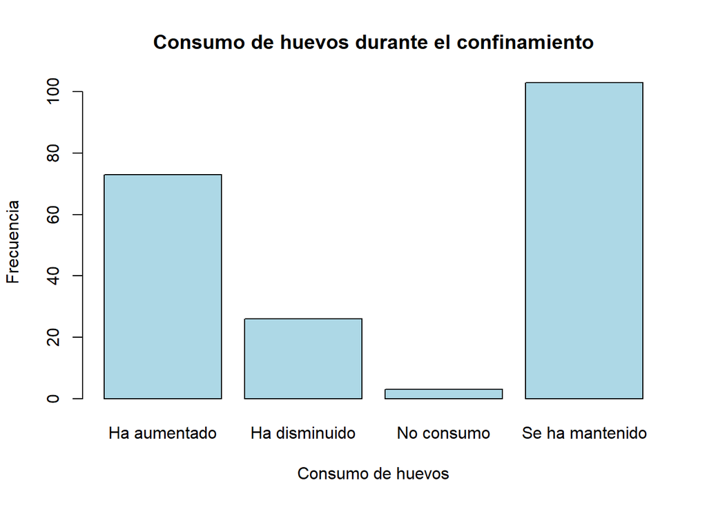

```r
counts <- table(BD$`Consumo de huevos durante el confinamiento`)
barplot(counts, main="Consumo de huevos durante el confinamiento", xlab = "Consumo de huevos", ylab = "Frecuencia",
        col=c("light blue"))
```

##### De este grafico podemos afirmar que durante el periodo de confinamiento los alumnos de la Universidad de Ingenieria y Tecnologia han mantenido el consumo de huevos en su alimentacion. Seguidamente de un grupo considerable que aumentaron el consumo del producto.

```r
cat('Número de observaciones:', nrow(BD),'\n')
```

```
## Número de observaciones: 205
```

```r
cat('Número de casos completos de la variable consumo de huevos durante el confinamiento:', sum(complete.cases(BD$`Consumo de huevos durante el confinamiento`)),'\n')
```

```
## Número de casos completos de la variable consumo de huevos durante el confinamiento: 205
```

##### El número de observaciones y el numero de casos completos para la variable del consumo de huevos durante el confinamiento es 205, por lo que la muestra selectiva para el análisis de esta variable es 205 observaciones.

```r
cat('Moda de la variable consumo de huevos durante el confinamiento:', "Se ha mantenido" ,'\n')
```

```
## Moda de la variable consumo de huevos durante el confinamiento: Se ha mantenido
```

##### Esta variable es de tipo cualitativa por lo que se determina la moda obteniendose que los estudiantes de UTEC en su mayoría ha mantenido el consumo de huevos durante el confinamiento, por lo que se podría decir que el confinamiento por el covid-19 no influyó en el consumo de huevos

### - *Consumo de lácteos durante el confinamiento:*

### **Análisis univariado:**

##### En esta variable se analizo el impacto durante el confinamiento en la frecuencia del consumo de lacteos en los estudiantes de UTEC, a continuación se analiza la frecuencia donde se obtuvo los siguientes resultados:

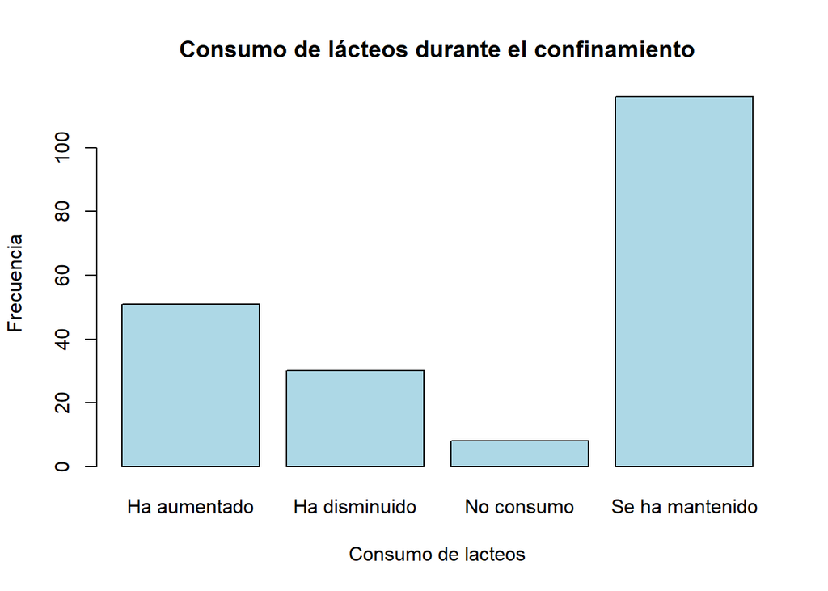

```r
counts <- table(BD$`Consumo de lácteos durante el confinamiento`)
barplot(counts, main="Consumo de lácteos durante el confinamiento", xlab = "Consumo de lacteos", ylab = "Frecuencia",
        col=c("light blue"))
```

##### De este grafico podemos afirmar que durante el periodo de confinamiento los alumnos de la Universidad de Ingenieria y Tecnologia han mantenido el consumo de lacteos en su alimentacion.

```r
cat('Número de observaciones:', nrow(BD),'\n')
```

```
## Número de observaciones: 205
```

```r
cat('Número de casos completos de la variable consumo de lacteos durante el confinamiento:', sum(complete.cases(BD$`Consumo de lácteos durante el confinamiento`)),'\n')
```

```
## Número de casos completos de la variable consumo de lacteos durante el confinamiento: 205
```

##### El número de observaciones y el numero de casos completos para la variable del consumo de lacteos durante el confinamiento es 205, por lo que la muestra selectiva para el análisis de esta variable es 205 observaciones.

```r
cat('Moda de la variable consumo de lacteos durante el confinamiento:', "Se ha mantenido" ,'\n')
```

```
## Moda de la variable consumo de lacteos durante el confinamiento: Se ha mantenido
```

##### Esta variable es de tipo cualitativa por lo que se determina la moda obteniendose que los estudiantes de UTEC ha mantenido el consumo de lacteos durante el confinamiento, de la misma forma podemos mencionar que el confinamiento no impactó en el consumo de laimentos de este rubro.

### - *Consumo de pan y cereales durante el confinamiento:*

### **Análisis univariado:**

##### En esta variable se analizo el impacto durante el confinamiento en la frecuencia del consumo de pan y cereales en los estudiantes de UTEC, a continuación se analiza la frecuencia donde se obtuvo los siguientes resultados:

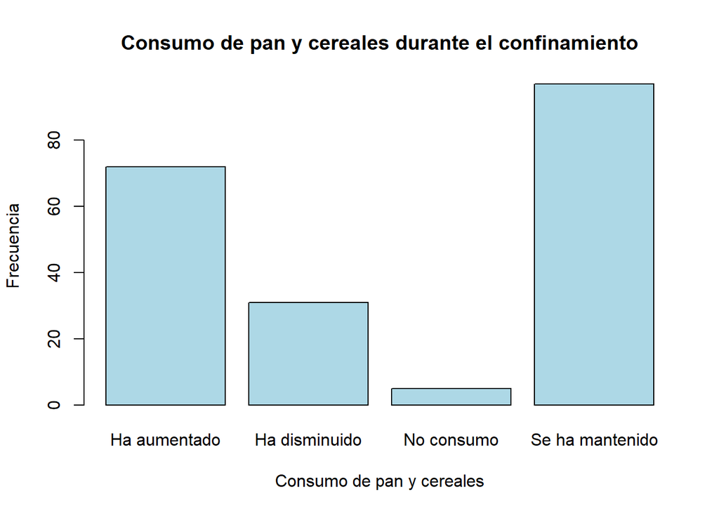

```r
counts <- table(BD$`Consumo de pan y cereales durante el confinamiento`)
barplot(counts, main="Consumo de pan y cereales durante el confinamiento", xlab = "Consumo de pan y cereales", ylab = "Frecuencia",
        col=c("light blue"))
```

##### De este grafico podemos afirmar que los alumnos de la Universidad de Ingenieria y Tecnologia han mantenido el consumo de pan y cereales durante el confinamiento. Seguidamente de una gran grupo de estudiantes que aumentaron el consumo de este producto.

```r
cat('Número de observaciones:', nrow(BD),'\n')
```

```
## Número de observaciones: 205
```

```r
cat('Número de casos completos de la variable consumo de pan y cereales durante el confinamiento:', sum(complete.cases(BD$`Consumo de pan y cereales durante el confinamiento`)),'\n')
```

```
## Número de casos completos de la variable consumo de pan y cereales durante el confinamiento: 205
```

#### El número de observaciones y el numero de casos completos para la variable de consumo de pan y cereales durante el confinamiento es 205, por lo que la muestra selectiva para el análisis de esta variable es 205 observaciones.

```r
cat('Moda de la variable consumo de pan y cereales durante el confinamiento:', "Se ha mantenido" ,'\n')
```

```
## Moda de la variable consumo de pan y cereales durante el confinamiento: Se ha mantenido
```

#### Esta variable es de tipo cualitativa por lo que se determina la moda obteniendose que los estudiantes de UTEC en su mayoría ha mantenido el consumo de consumo de pan y cereales durante el confinamiento, en este rubro tampoco hubo un impacto del confinamiento.

### - *Consumo de suplementos de vitaminas durante el confinamiento:*

### **Análisis univariado:**

##### En esta variable se analizo el impacto durante el confinamiento en la frecuencia del consumo de suplementos de vitaminas en los estudiantes de UTEC, a continuacion se analiza la frecuencia donde se obtuvo los siguientes resultados:

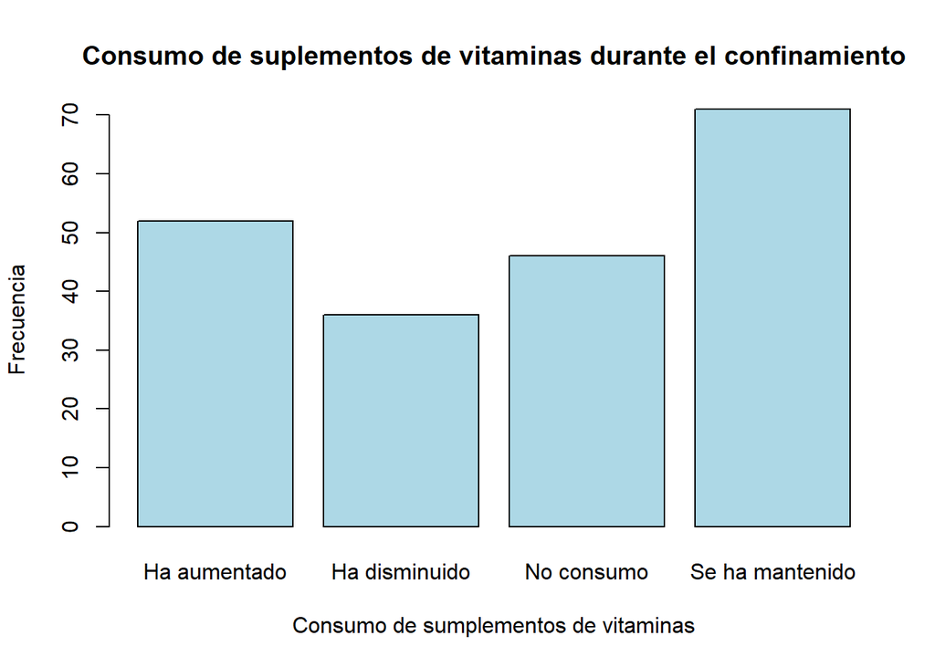

```r
counts <- table(BD$`Consumo de suplementos de vitaminas durante el confinamiento`)
barplot(counts, main="Consumo de suplementos de vitaminas durante el confinamiento", xlab = "Consumo de sumplementos de vitaminas", ylab = "Frecuencia",
        col=c("light blue"))
```

```r
cat('Número de observaciones:', nrow(BD),'\n')
```

```
## Número de observaciones: 205
```

```r
cat('Número de casos completos de la variable consumo de suplementos de vitaminas durante el confinamiento:', sum(complete.cases(BD$`Consumo de suplementos de vitaminas durante el confinamiento`)),'\n')
```

```
## Número de casos completos de la variable consumo de suplementos de vitaminas durante el confinamiento: 205
```

##### El número de observaciones y el numero de casos completos para la variable de consumo de suplementos de vitaminas durante el confinamiento es 205, por lo que la muestra selectiva para el análisis de esta variable es 205 observaciones.

```r
cat('Moda de la variable de consumo suplementos de vitaminas durante el confinamiento:', "Se ha mantenido" ,'\n')
```

```
## Moda de la variable de consumo suplementos de vitaminas durante el confinamiento: Se ha mantenido
```

##### Esta variable es de tipo cualitativa por lo que se determina la moda obteniendose que un gran grupo de los estudiantes de UTEC ha mantenido el consumo de suplementos de vitaminas durante el confinamiento.